# Hw1

# Question 1

Variables

```r
tv=c(44, 47, 50, 71, 33, 42, 46, 52, 39, 55, 62, 70, 44, 49, 50)
happiness=c(256, 251, 267, 376, 170, 210, 322, 274, 215, 272, 337, 368, 224, 276, 294)
```

analysis

```r
model = lm(happiness~tv)
summary(model)
```

```
##
## Call:
## lm(formula = happiness ~ tv)
##
## Residuals:
##     Min      1Q  Median      3Q     Max
## -25.964 -13.031  -5.482   6.019  69.348
##
## Coefficients:
##             Estimate Std. Error t value Pr(>|t|)
## (Intercept)   21.062     31.043   0.678    0.509
## tv             5.035      0.605   8.321 1.45e-06 ***
## ---
## Signif. codes:  0 '***' 0.001 '**' 0.01 '*' 0.05 '.' 0.1 ' ' 1
##
## Residual standard error: 24.09 on 13 degrees of freedom
## Multiple R-squared:  0.8419, Adjusted R-squared:  0.8298
## F-statistic: 69.24 on 1 and 13 DF,  p-value: 1.45e-06
```

## a) Estimate the regression line:

Y = 21.062 + 5.035(tv)

## b) Interpret B_o and B_1:

B_1 is the unit of increase in happiness per unit value increase of tv watched

## c) Test whether or not a linear association exists between happiness and amount of tv one watches. State your hypotheses and your conclusions.

Ho = B1 = 0

t = B1 / sterr (b1)

```r
5.035/0.605
```

```
## [1] 8.322314
```

## d) Interpret R^2

R^2 represents the proportion of variance in the dependent variable that is predictable from the independent variable.

## e) plot the estimated regression line and the data.

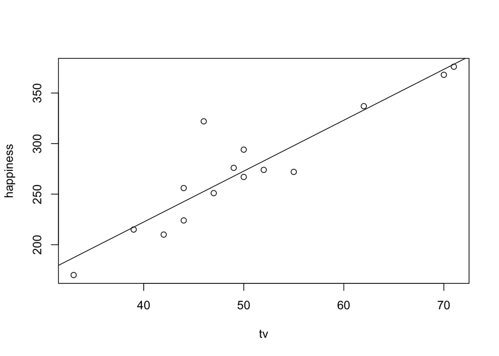

```r
plot(tv, happiness, abline(lm(happiness~tv)))
```

## f) Verify the assumptions

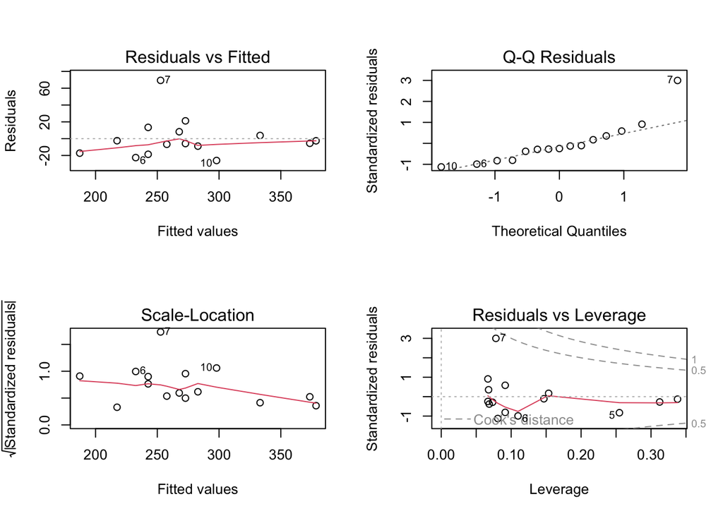

```r
par(mfrow = c(2,2))
plot(model)
```

Linearity: Plot 1 shows no curve; relatively flat therefore confirming linearity

Constant Variance: Plot 1 shows no funnel shape confirms constant variance

Normality: Plot 2 shows values that align relatively well around a trendline; therefore normality is confirmed.

Outlier: value 7 deviates from other values in the plots revealing that it is an outlier

## Notes

plot 1 tests assumptions of linearity and constant variance.

- a curve here would indicate assumption of linearity is violated.
- a funnel indicates constant variance is violated.
- random scatter around zero means we pass both assumptions of linearity and constant variance

Plot 2: Normal Q-Q plot

- tests normality:
  - normal: linear line
  - violation: no line